# GEOG606 - HW1

Anika Cartas

Saturday, February 14, 2015

#### 1. Solve the following linear equations:

-x + 2y = 1

3x + y = 3

```r
left = matrix(c(-1,3,2,1,1,3),2,2); left
```

```
##      [,1] [,2]
## [1,]   -1    2
## [2,]    3    1
```

```r
right = c(1,3); right
```

```
## [1] 1 3
```

```r
solve(left,right)
```

```
## [1] 0.7142857 0.8571429
```

**If we add another equation, x + y = 2, is there a solution for the set of 3 equations?**

- No. We can only solve for a square matrix.

**If not, could you give a best estimate of x and y that satisfy the equations?**

- To find a best estimate, plot all three lines and find the centerpoint of the triangle their intersections create.

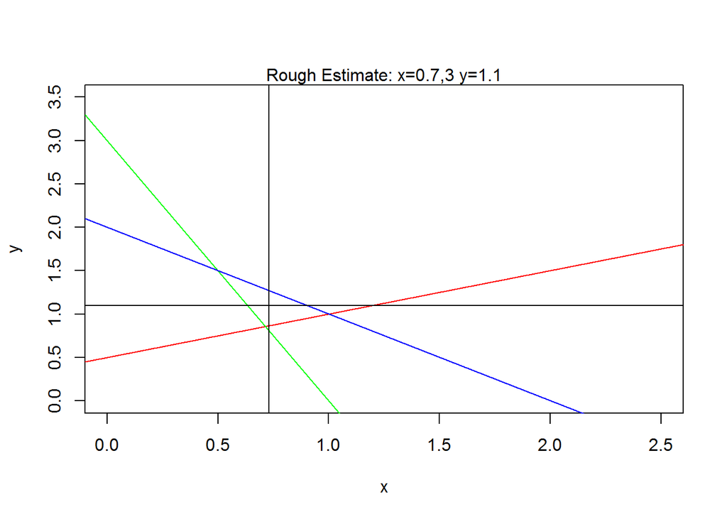

```r
#Plot all three lines
plot(NULL,xlim=c(0,2.5),ylim=c(0,3.5), xlab="x",ylab="y")
abline(1/2,1/2, col="red") #first first equation
abline(3,-3,col="green") #second equation
abline(2,-1,col="blue") #third equation
abline(h=1.1)
abline(v=0.73)
mtext("Rough Estimate: x=0.7,3 y=1.1")
```

#### 2. Calculate the covariance matrix of the following 3*2 data matrix:

First, calculate by hand:

$A = \left( \begin{array}{cc} 1 & 3 \\ 2 & 2 \\ 3 & 1 \end{array} \right)$

1. Calculate the matrix of devation scores, with n = nrows(A):

$a = A - 11\cdot A/{n} \\ a = \left( \begin{array}{cc} 1 & 3 \\ 2 & 2 \\ 3 & 1 \end{array} \right) - \left( \begin{array}{ccc} 1 & 1 & 1 \\ 1 & 1 & 1 \\ 1 & 1 & 1 \end{array} \right)\left( \begin{array}{cc} 1 & 3 \\ 2 & 2 \\ 3 & 1 \end{array} \right) \cdot\frac{1}{3} \\ a = \left( \begin{array}{cc} 1 & 3 \\ 2 & 2 \\ 3 & 1 \end{array} \right) - \left(\begin{array}{cc} 6 & 6 \\ 6 & 6 \\ 6 & 6\end{array} \right)\cdot\frac{1}{3} \\ a = \left( \begin{array}{cc} 1 & 3 \\ 2 & 2 \\ 3 & 1 \end{array} \right) - \left(\begin{array}{cc} 2 & 2 \\ 2 & 2 \\ 2 & 2\end{array} \right) \\ a = \left( \begin{array}{cc} -1 & 1 \\ 0 & 0 \\ 1 & -1 \end{array}\right)$

Now, calculate using R. So much easier!

```r
x = matrix(c(1,2,3,3,2,1),3,2); x
```

```
##      [,1] [,2]
## [1,]    1    3
## [2,]    2    2
## [3,]    3    1
```

```r
cov(x)
```

```
##      [,1] [,2]
## [1,]    1   -1
## [2,]   -1    1
```

**What does the covariance tell you about the data?**

- The covariance matrix shows the variances of the two variables (x,y) along the diagonal, and the covariances between them in the other positions.
- In this case, the variance of both x and y is 1, while their covariance is -1, meaning that as x grows y shrinks, and vice versa.

#### 3.Use the following dataset to demonstrate the Central Tendency Theorem:

```r
data = c(3,2,3,4,3,2,5,4,5,2,3,3,10,4,5,4,12,15,10,17,15,18,16,14,9,10,11,18,17,18,16,17,18)
```

**3.1. Randomly select 5 values and calculate their mean.**

```r
s1 = sample(data,5); s1
```

```
## [1] 16  4 10  3  3
```

```r
mean(s1)
```

```
## [1] 7.2
```

**Repeat 3 times, and calculate the mean of the sampling mean. Then, repeat 5, 10, 20, and 50 times.**

```r
#Calculate the mean of 'size' samples of 'sampleSize' from data, repeating for each size given in sizes. Return a formatted matrix of these means.
takeSamples <- function(data,sizes, sampleSize){
  allMeans = matrix(NA,1,2)
  for (n in sizes){
    curMeans = vector()
    for (i in c(1:n)){
      curMeans = c(curMeans,mean(sample(data,sampleSize)))
    }
    allMeans = rbind(allMeans,c(n,mean(curMeans)))
  }
  allMeans = allMeans[-1,]
  colnames(allMeans) = c("Times.Sampled","Mean")
  allMeans #return value
}
```

Requested means from 3,5,10,20, and 50 repetitions of sampling of size 5.

```r
means.5 = takeSamples(data,c(3,5,10,20,50),sampleSize=5); means.5
```

```
##      Times.Sampled      Mean
## [1,]             3  7.866667
## [2,]             5 10.000000
## [3,]            10  8.860000
## [4,]            20  8.840000
## [5,]            50  9.684000
```

**Use a plot to show how the mean of the sampling mean changes as the number of repeats increases.**

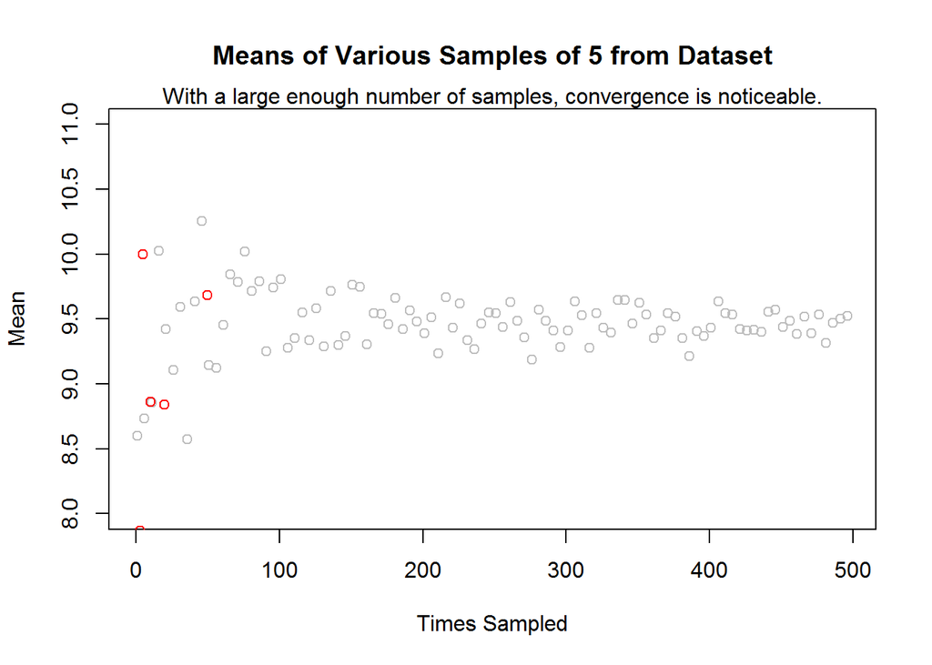

```r
#Out of curiosity, plotting larger sizes of samples (first, so that axes match up)
means.5.500 = takeSamples(data,seq(1,500,5),sampleSize=5)
plot(means.5.500, main="Means of Various Samples of 5 from Dataset", col="grey", xlab="Times Sampled", ylim=c(8,11))

#Request from assignment in red
points(means.5,col="red")

mtext("With a large enough number of samples, convergence is noticeable.")
```

**3.2. Repeat 3.1. but select 10 values during each random selection. Explain these plots in relation to the Central Tendency Theorem.**

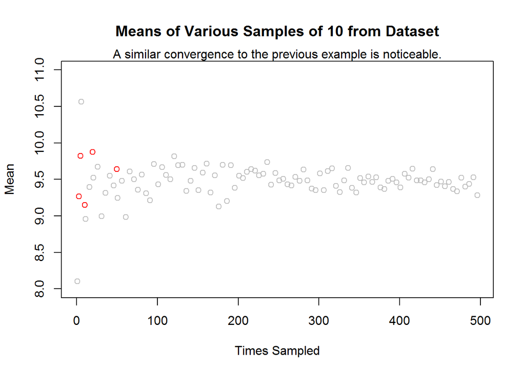

```r
means.10.500 = takeSamples(data,seq(1,500,5),sampleSize=10)

plot(means.10.500, main="Means of Various Samples of 10 from Dataset", col="grey", xlab="Times Sampled", ylim=c(8,11))

#Request from assignment in red
means.10 = takeSamples(data,c(3,5,10,20,50),sampleSize=10)
points(means.10, col="red")

mtext("A similar convergence to the previous example is noticeable.")
```

**3.3. How does the sampling mean approach normal distribution in these experiments? Use histograms to show.**

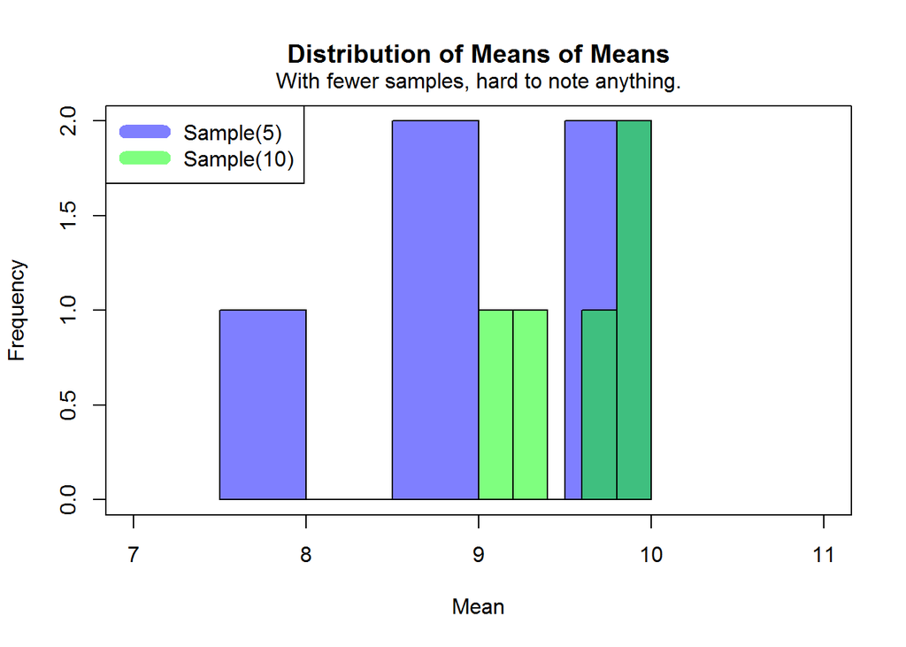

```r
hist(means.5[,2], col=rgb(0,0,1,0.5), xlim=c(7,11),main="Distribution of Means of Means", xlab="Mean")

hist(means.10[,2], col=rgb(0,1,0,0.5), xlab="Mean", add=T)

legend("topleft", c("Sample(5)","Sample(10)"),col=c(rgb(0,0,1,0.5),rgb(0,1,0,0.5)), lwd=10)
box() #decorative box around data
mtext("With fewer samples, hard to note anything.",line=0.5)
```

[figure not shown]

```r
hist(means.10.500[,2], col=rgb(0,0,1,0.5), main="Distribution of Means of Means", xlab="Mean")

hist(means.5.500[,2], col=rgb(0,1,0,0.5), xlab="Mean", add=T)

legend("topright", c("Sample(5)","Sample(10)"),col=c(rgb(0,0,1,0.5),rgb(0,1,0,0.5)), lwd=10)
box() #decorative box around data
mtext("With more samples, a normal curve with median 9.5 is noticeable.",line=0.5)
```